# PM566 Homework 2

Author

Jordan Walton

## Question 1

**Answer**:

**ORD**: 17283

**ATL**: 17215

**LAX**: 16174

**BOS**: 15508

**MCO**: 14082

**CLT**: 14064

**SFO**: 13331

**FLL**: 12055

**MIA**: 11728

**DCA**: 9705

```r
flights %>%
  count(dest, sort = TRUE) %>%
  top_n(10)
```

```
# A tibble: 10 × 2
   dest      n
   <chr> <int>
 1 ORD   17283
 2 ATL   17215
 3 LAX   16174
 4 BOS   15508
 5 MCO   14082
 6 CLT   14064
 7 SFO   13331
 8 FLL   12055
 9 MIA   11728
10 DCA    9705
```

## Question 2

**Answer**: The percentage of the flights that were “red eye” were 3.15%.

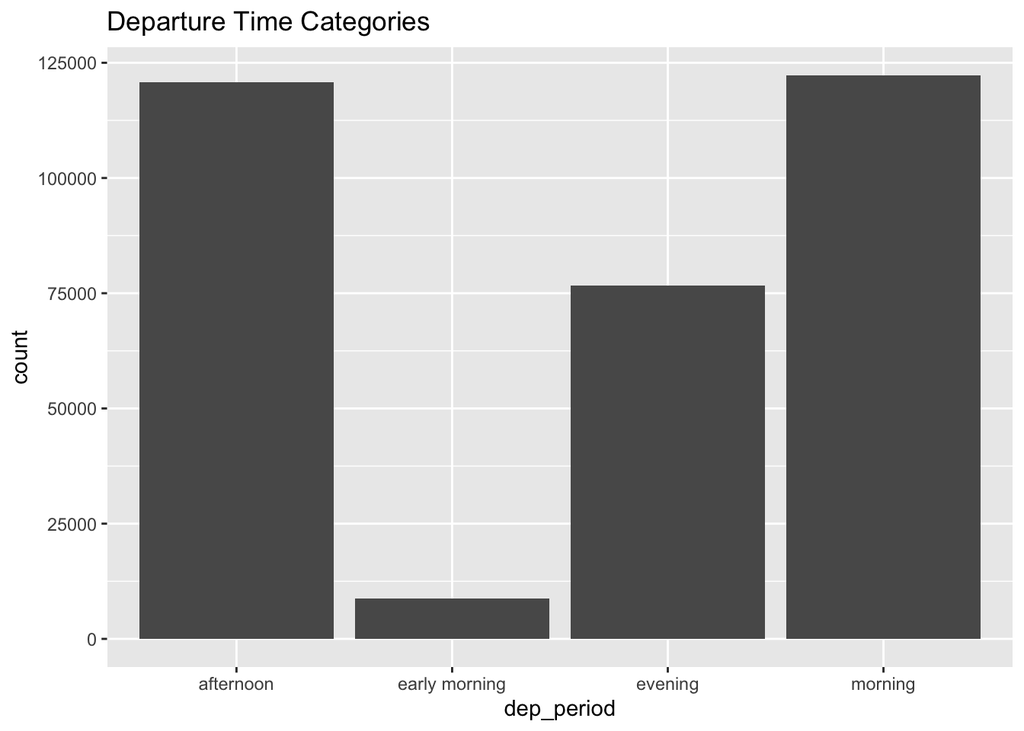

```r
# Helper function
get_time_category <- function(time) {
  hour <- floor(time / 100)
  case_when(
    hour >= 0 & hour < 6 ~ "early morning",
    hour >= 6 & hour < 12 ~ "morning",
    hour >= 12 & hour < 18 ~ "afternoon",
    hour >= 18 & hour <= 23 ~ "evening",
    TRUE ~ NA_character_
  )
}

# Create new variables
flights <- flights %>%
  mutate(
    dep_period = get_time_category(dep_time),
    arr_period = get_time_category(arr_time)
  )

# Barplots
ggplot(flights %>% filter(!is.na(dep_period)), aes(x = dep_period)) +
  geom_bar() +
  ggtitle("Departure Time Categories")
```

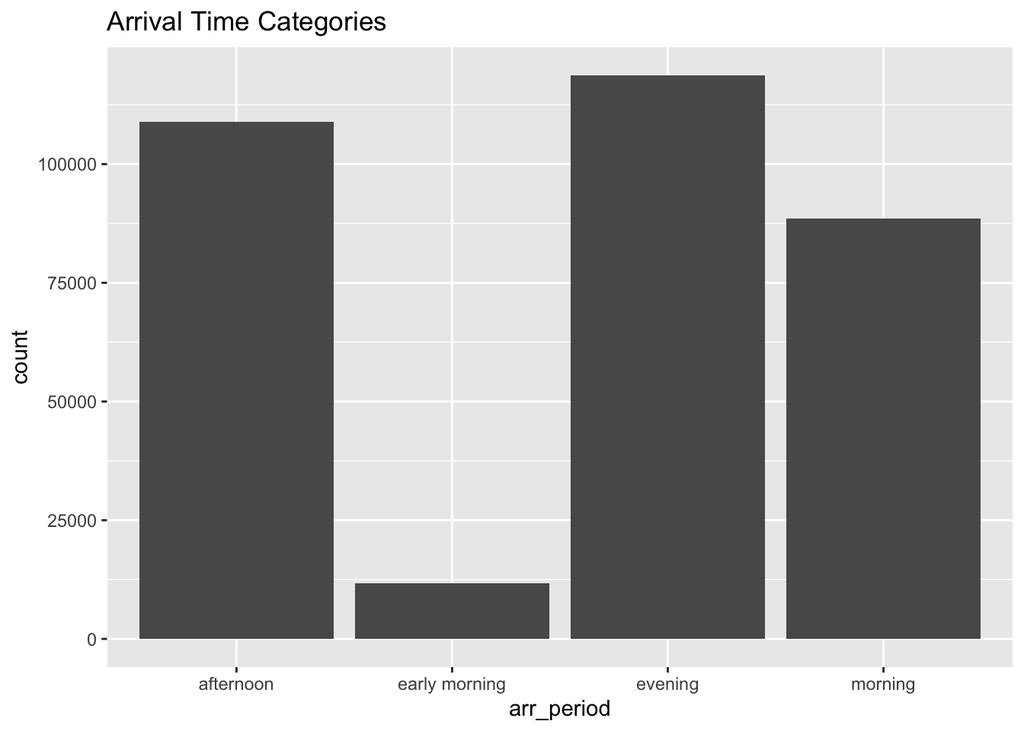

```r
ggplot(flights %>% filter(!is.na(arr_period)), aes(x = arr_period)) +
  geom_bar() +
  ggtitle("Arrival Time Categories")
```

```r
# Red eye flights
red_eye <- flights %>%
  filter(dep_period %in% c("afternoon", "evening"),
         arr_period %in% c("early morning", "morning"))

red_eye_pct <- nrow(red_eye) / nrow(flights) * 100
red_eye_pct
```

```
[1] 3.14868
```

## Question 3

```r
flights %>%
  filter(!is.na(tailnum)) %>%
  distinct(tailnum, carrier) %>%
  count(tailnum) %>%
  filter(n > 1) %>%
  left_join(flights %>% select(tailnum, carrier) %>% distinct(), by = "tailnum")
```

```
# A tibble: 34 × 3
   tailnum     n carrier
   <chr>   <int> <chr>
 1 N146PQ      2 9E
 2 N146PQ      2 EV
 3 N153PQ      2 9E
 4 N153PQ      2 EV
 5 N176PQ      2 9E
 6 N176PQ      2 EV
 7 N181PQ      2 9E
 8 N181PQ      2 EV
 9 N197PQ      2 9E
10 N197PQ      2 EV
# ℹ 24 more rows
```

## Question 4

**Answer**: The missing relationship is between weather$origin and airports$faa. Each weather observation is tied to a specific airport, so this connection should be represented in the diagram. Adding an arrow from weather to airports via the origin → faa link would complete the relational structure and clarify how weather data can be joined with airport metadata.

## Question 5

**Answer**: After creating a weather_id using year, month, day, hour, and origin, we found 3 duplicated entries. This indicates that for three specific airport-hour combinations, there were multiple weather observations recorded. These duplicates may result from overlapping measurements or data granularity within the same hour. While rare, they highlight the importance of verifying uniqueness before merging data sets.

```r
weather <- weather %>%
  mutate(weather_id = paste(year, month, day, hour, origin, sep = "_"))

# Check duplicates
sum(duplicated(weather$weather_id))
```

```
[1] 3
```

```r
# Merge
flights_weather <- flights %>%
  left_join(weather, by = c("time_hour", "origin"))

# column cleanup

flights_weather <- flights_weather %>%
  rename(
    year = year.x,
    month = month.x,
    day = day.x,
    hour = hour.x
  ) %>%
  select(-year.y, -month.y, -day.y, -hour.y)
```

## Question 6

```r
# Step 2: Missing values
summary(flights_weather)
```

```
      year          month             day           dep_time    sched_dep_time
 Min.   :2013   Min.   : 1.000   Min.   : 1.00   Min.   :   1   Min.   : 106
 1st Qu.:2013   1st Qu.: 4.000   1st Qu.: 8.00   1st Qu.: 907   1st Qu.: 906
 Median :2013   Median : 7.000   Median :16.00   Median :1401   Median :1359
 Mean   :2013   Mean   : 6.549   Mean   :15.71   Mean   :1349   Mean   :1344
 3rd Qu.:2013   3rd Qu.:10.000   3rd Qu.:23.00   3rd Qu.:1744   3rd Qu.:1729
 Max.   :2013   Max.   :12.000   Max.   :31.00   Max.   :2400   Max.   :2359
                                                 NA's   :8255
   dep_delay          arr_time    sched_arr_time   arr_delay
 Min.   : -43.00   Min.   :   1   Min.   :   1   Min.   : -86.000
 1st Qu.:  -5.00   1st Qu.:1104   1st Qu.:1124   1st Qu.: -17.000
 Median :  -2.00   Median :1535   Median :1556   Median :  -5.000
 Mean   :  12.64   Mean   :1502   Mean   :1536   Mean   :   6.895
 3rd Qu.:  11.00   3rd Qu.:1940   3rd Qu.:1945   3rd Qu.:  14.000
 Max.   :1301.00   Max.   :2400   Max.   :2359   Max.   :1272.000
 NA's   :8255      NA's   :8713                  NA's   :9430
   carrier              flight       tailnum             origin
 Length:336776      Min.   :   1   Length:336776      Length:336776
 Class :character   1st Qu.: 553   Class :character   Class :character
 Mode  :character   Median :1496   Mode  :character   Mode  :character
                    Mean   :1972
                    3rd Qu.:3465
                    Max.   :8500

     dest              air_time        distance         hour
 Length:336776      Min.   : 20.0   Min.   :  17   Min.   : 1.00
 Class :character   1st Qu.: 82.0   1st Qu.: 502   1st Qu.: 9.00
 Mode  :character   Median :129.0   Median : 872   Median :13.00
                    Mean   :150.7   Mean   :1040   Mean   :13.18
                    3rd Qu.:192.0   3rd Qu.:1389   3rd Qu.:17.00
                    Max.   :695.0   Max.   :4983   Max.   :23.00
                    NA's   :9430
     minute        time_hour                    dep_period
 Min.   : 0.00   Min.   :2013-01-01 05:00:00   Length:336776
 1st Qu.: 8.00   1st Qu.:2013-04-04 13:00:00   Class :character
 Median :29.00   Median :2013-07-03 10:00:00   Mode  :character
 Mean   :26.23   Mean   :2013-07-03 05:22:54
 3rd Qu.:44.00   3rd Qu.:2013-10-01 07:00:00
 Max.   :59.00   Max.   :2013-12-31 23:00:00

```

[output cut: 9 more lines]

```
 Min.   :  0.0   Min.   : 0.000   Min.   :16.11    Min.   :0.00000
 1st Qu.:130.0   1st Qu.: 6.905   1st Qu.:20.71    1st Qu.:0.00000
 Median :220.0   Median :10.357   Median :24.17    Median :0.00000
 Mean   :201.5   Mean   :11.114   Mean   :25.25    Mean   :0.00456
 3rd Qu.:290.0   3rd Qu.:14.960   3rd Qu.:28.77    3rd Qu.:0.00000
 Max.   :360.0   Max.   :42.579   Max.   :66.75    Max.   :1.21000
 NA's   :9796    NA's   :1634     NA's   :256391   NA's   :1556
    pressure          visib         weather_id
 Min.   : 983.8   Min.   : 0.000   Length:336776
 1st Qu.:1012.7   1st Qu.:10.000   Class :character
 Median :1017.5   Median :10.000   Mode  :character
 Mean   :1017.8   Mean   : 9.256
 3rd Qu.:1022.8   3rd Qu.:10.000
 Max.   :1042.1   Max.   :10.000
 NA's   :38788    NA's   :1556
```

```r
# Step 3: Variable types
glimpse(flights_weather)
```

```
Rows: 336,776
Columns: 31
$ year           <int> 2013, 2013, 2013, 2013, 2013, 2013, 2013, 2013, 2013, 2…
$ month          <int> 1, 1, 1, 1, 1, 1, 1, 1, 1, 1, 1, 1, 1, 1, 1, 1, 1, 1, 1…
$ day            <int> 1, 1, 1, 1, 1, 1, 1, 1, 1, 1, 1, 1, 1, 1, 1, 1, 1, 1, 1…
$ dep_time       <int> 517, 533, 542, 544, 554, 554, 555, 557, 557, 558, 558, …
$ sched_dep_time <int> 515, 529, 540, 545, 600, 558, 600, 600, 600, 600, 600, …
$ dep_delay      <dbl> 2, 4, 2, -1, -6, -4, -5, -3, -3, -2, -2, -2, -2, -2, -1…
$ arr_time       <int> 830, 850, 923, 1004, 812, 740, 913, 709, 838, 753, 849,…
$ sched_arr_time <int> 819, 830, 850, 1022, 837, 728, 854, 723, 846, 745, 851,…
$ arr_delay      <dbl> 11, 20, 33, -18, -25, 12, 19, -14, -8, 8, -2, -3, 7, -1…
$ carrier        <chr> "UA", "UA", "AA", "B6", "DL", "UA", "B6", "EV", "B6", "…
$ flight         <int> 1545, 1714, 1141, 725, 461, 1696, 507, 5708, 79, 301, 4…
$ tailnum        <chr> "N14228", "N24211", "N619AA", "N804JB", "N668DN", "N394…
$ origin         <chr> "EWR", "LGA", "JFK", "JFK", "LGA", "EWR", "EWR", "LGA",…
```

[output cut: 18 more lines]

```r
# Step 4: Range and distribution
flights_weather %>%
  select(dep_delay, arr_delay, temp, wind_speed, precip) %>%
  summary()
```

```
   dep_delay         arr_delay             temp          wind_speed
 Min.   : -43.00   Min.   : -86.000   Min.   : 10.94   Min.   : 0.000
 1st Qu.:  -5.00   1st Qu.: -17.000   1st Qu.: 42.08   1st Qu.: 6.905
 Median :  -2.00   Median :  -5.000   Median : 57.20   Median :10.357
 Mean   :  12.64   Mean   :   6.895   Mean   : 57.00   Mean   :11.114
 3rd Qu.:  11.00   3rd Qu.:  14.000   3rd Qu.: 71.96   3rd Qu.:14.960
 Max.   :1301.00   Max.   :1272.000   Max.   :100.04   Max.   :42.579
 NA's   :8255      NA's   :9430       NA's   :1573     NA's   :1634
     precip
 Min.   :0.00000
 1st Qu.:0.00000
 Median :0.00000
 Mean   :0.00456
 3rd Qu.:0.00000
 Max.   :1.21000
 NA's   :1556
```

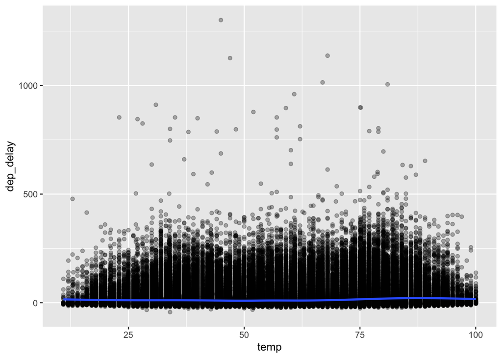

```r
# Step 5: Relationships
ggplot(flights_weather, aes(x = temp, y = dep_delay)) + geom_point(alpha = 0.3) + geom_smooth()
```

## Question 7

**Answer**:

1. Worst overall day: March 8, 2013
2. Worst day at a specific airport: March 8, 2013 at LGA
3. Worst hour at a specific airport: On July 28th, 2013 at 9, LGA had the worst single hour for delays

```r
# Worst overall day
worst_day <- flights_weather %>%
  group_by(year, month, day) %>%
   summarise(avg_dep_delay = mean(dep_delay, na.rm = TRUE), .groups = "drop") %>%
  arrange(desc(avg_dep_delay)) %>%
  slice(1)

# Worst day at a specific airport
worst_day_origin <- flights_weather %>%
  group_by(year, month, day, origin) %>%
   summarise(avg_dep_delay = mean(dep_delay, na.rm = TRUE), .groups = "drop") %>%
  arrange(desc(avg_dep_delay)) %>%
  slice(1)

# Worst hour at a specific airport
worst_hour_origin <- flights_weather %>%
  group_by(year, month, day, hour, origin) %>%
   summarise(avg_dep_delay = mean(dep_delay, na.rm = TRUE), .groups = "drop") %>%
  arrange(desc(avg_dep_delay)) %>%
  slice(1)
```

## Question 8

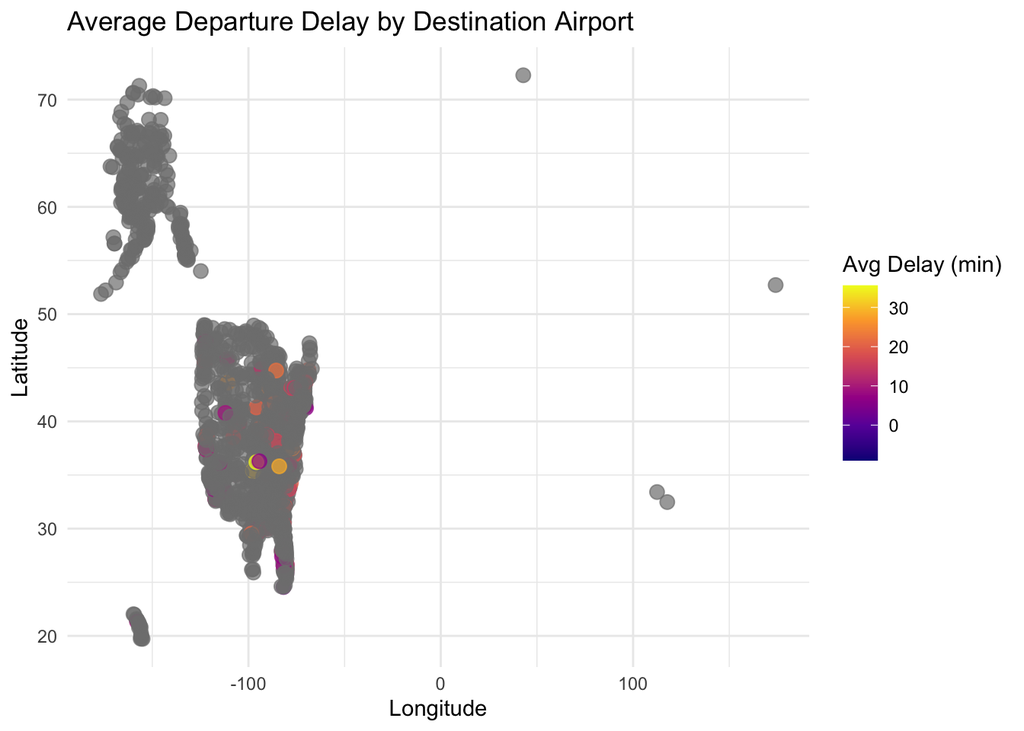

```r
avg_delay_dest <- flights_weather %>%
  group_by(dest) %>%
  summarise(avg_dep_delay = mean(dep_delay, na.rm = TRUE))

#adding information to the airpots data frame
airport_delays <- airports %>%
  left_join(avg_delay_dest, by = c("faa" = "dest"))

# plotting a map

ggplot(airport_delays, aes(x = lon, y = lat, color = avg_dep_delay)) +
  geom_point(size = 3, alpha = 0.7) +
  scale_color_viridis_c(option = "plasma", na.value = "grey50") +
  theme_minimal() +
  labs(title = "Average Departure Delay by Destination Airport",
       x = "Longitude", y = "Latitude", color = "Avg Delay (min)")
```

## Question 9

**Answer**: Based on the visualizations and summary statistics, precipitation has the strongest impact on departure delays, followed by wind speed. Temperature shows little to no consistent effect. Flights departing during heavy rain or high wind conditions are more likely to experience longer delays, highlighting the operational challenges posed by adverse weather.

```r
set.seed(42)  # For reproducibility

flights_weather_clean <- flights_weather %>%
  filter(!is.na(dep_delay), dep_delay < 300)  # Remove extreme delays

sampled_data <- flights_weather_clean %>% sample_n(5000)
```

```r
weather_summary <- flights_weather_clean %>%
  mutate(
    temp_bin = cut(temp, breaks = c(0, 32, 50, 70, 90, 110), include.lowest = TRUE),
    wind_bin = cut(wind_speed, breaks = c(0, 5, 10, 15, 20, 30), include.lowest = TRUE),
    precip_bin = cut(precip, breaks = c(0, 0.01, 0.1, 0.5, 1, 2), include.lowest = TRUE)
  ) %>%
  group_by(temp_bin, wind_bin, precip_bin) %>%
  summarise(avg_dep_delay = mean(dep_delay, na.rm = TRUE), .groups = "drop") %>%
  arrange(desc(avg_dep_delay))

weather_summary
```

```
# A tibble: 82 × 4
   temp_bin wind_bin precip_bin avg_dep_delay
   <fct>    <fct>    <fct>              <dbl>
 1 (70,90]  [0,5]    (1,2]              113.
 2 [0,32]   (10,15]  (0.1,0.5]           96.0
 3 (50,70]  <NA>     (0.1,0.5]           95.4
 4 (70,90]  <NA>     (0.01,0.1]          95.3
 5 (70,90]  (15,20]  (0.1,0.5]           72.5
 6 (70,90]  (15,20]  (0.5,1]             70.9
 7 (70,90]  (15,20]  (0.01,0.1]          64.1
 8 (70,90]  (20,30]  (0.01,0.1]          56.4
 9 (32,50]  <NA>     (0.01,0.1]          54.8
10 (70,90]  (5,10]   (0.01,0.1]          54.6
# ℹ 72 more rows
```

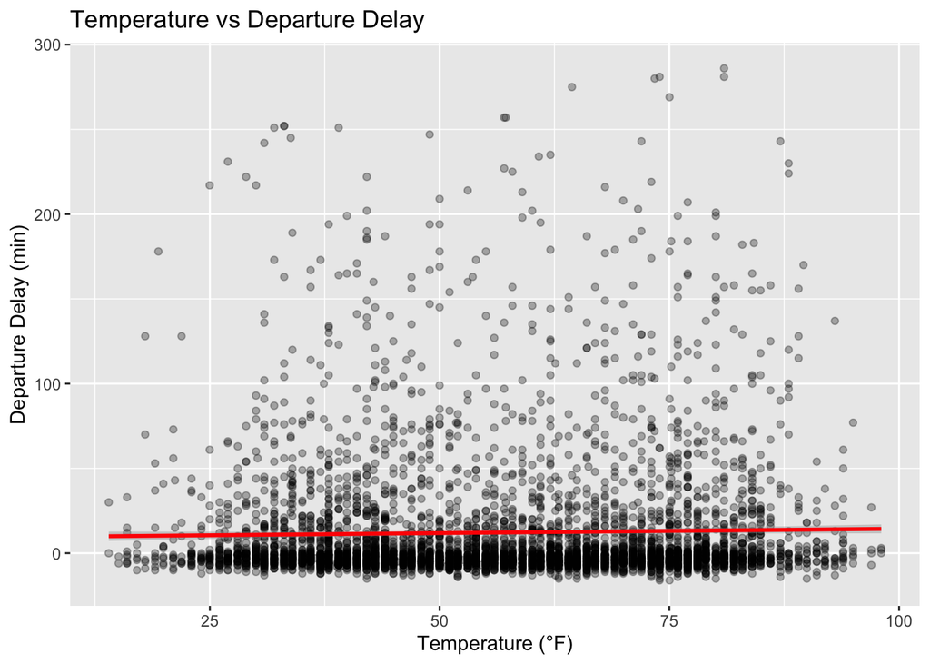

```r
#Temperature vs Departure Delay

ggplot(sampled_data, aes(x = temp, y = dep_delay)) +
  geom_point(alpha = 0.3) +
  geom_smooth(method = "lm", color = "red") +
  labs(title = "Temperature vs Departure Delay",
       x = "Temperature (°F)", y = "Departure Delay (min)")
```

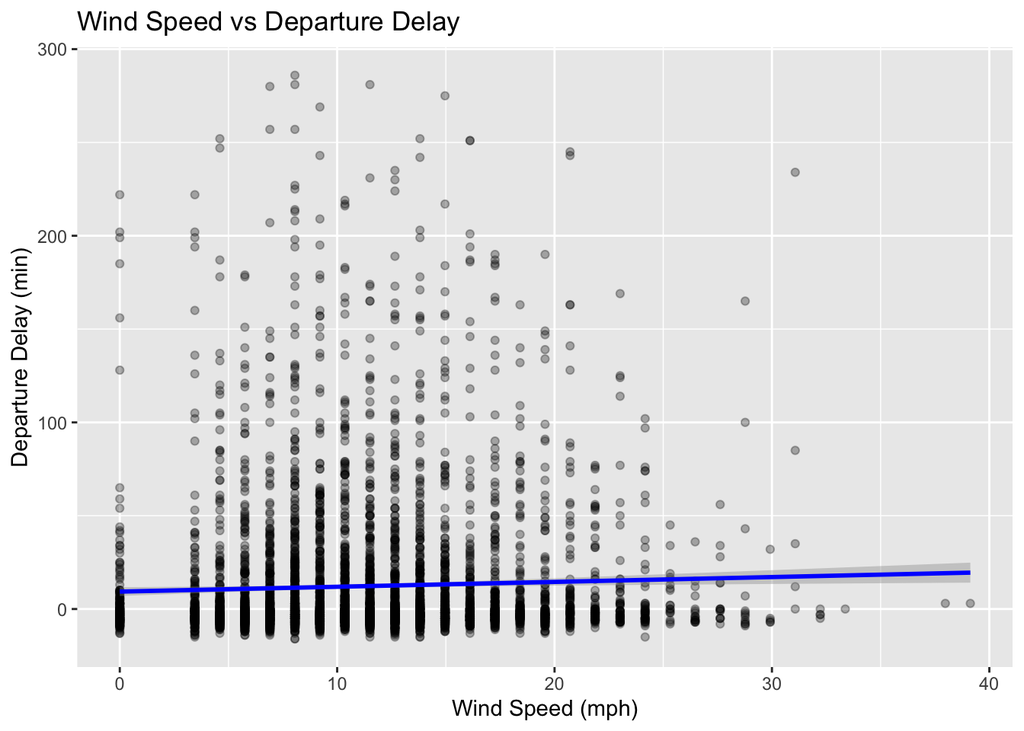

```r
# Wind Speed vs Departure Delay
ggplot(sampled_data, aes(x = wind_speed, y = dep_delay)) +
  geom_point(alpha = 0.3) +
  geom_smooth(method = "lm", color = "blue") +
  labs(title = "Wind Speed vs Departure Delay",
       x = "Wind Speed (mph)", y = "Departure Delay (min)")
```

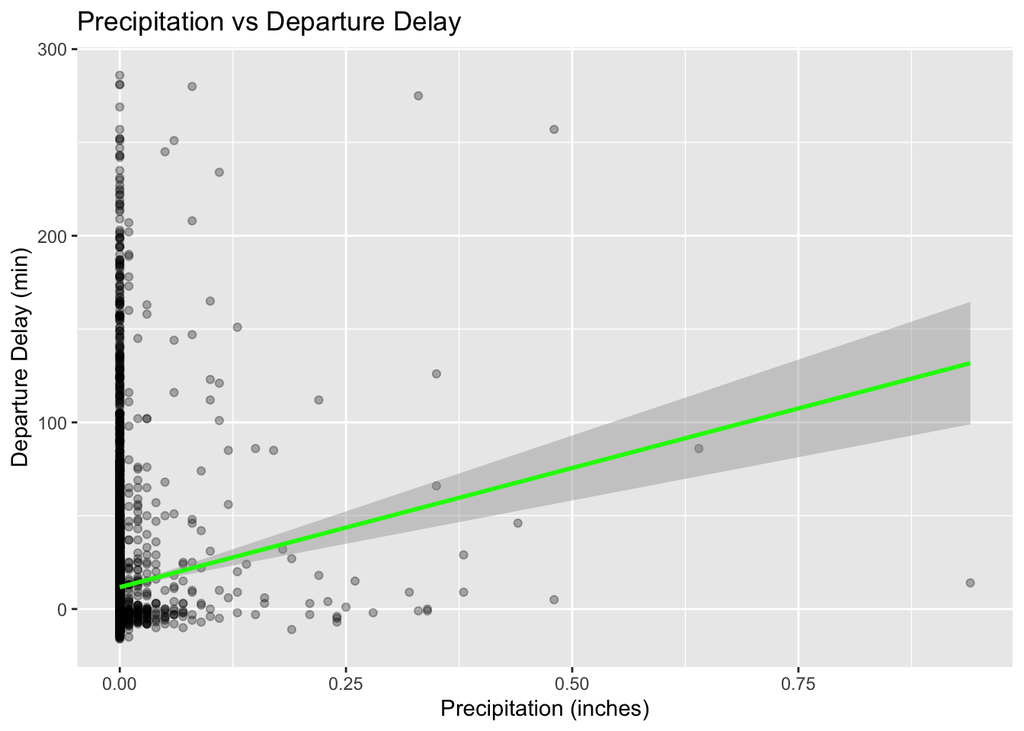

```r
# Precipitation vs Departure Delay

ggplot(sampled_data, aes(x = precip, y = dep_delay)) +
  geom_point(alpha = 0.3) +
  geom_smooth(method = "lm", color = "green") +
  labs(title = "Precipitation vs Departure Delay",
       x = "Precipitation (inches)", y = "Departure Delay (min)")
```